# Forecasting US Mortgage Rates

We have been gven the data of mortgage rates in US since 2005 to 2019. Using ARIMA the rates have been forecasted for the next 50 weeks.

1)Data Visuualization

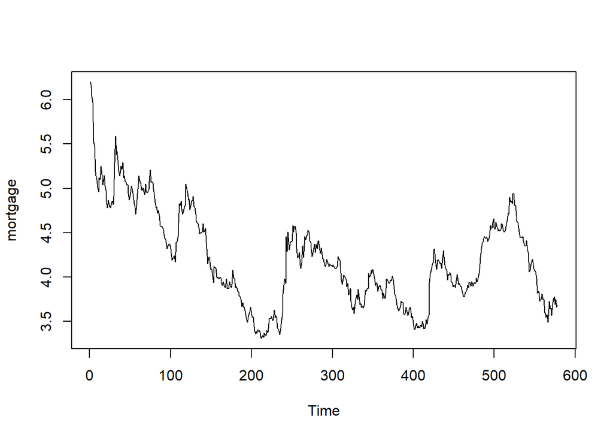

```r
par(mfrow=c(1,1))
plot.ts(mortgage)
```

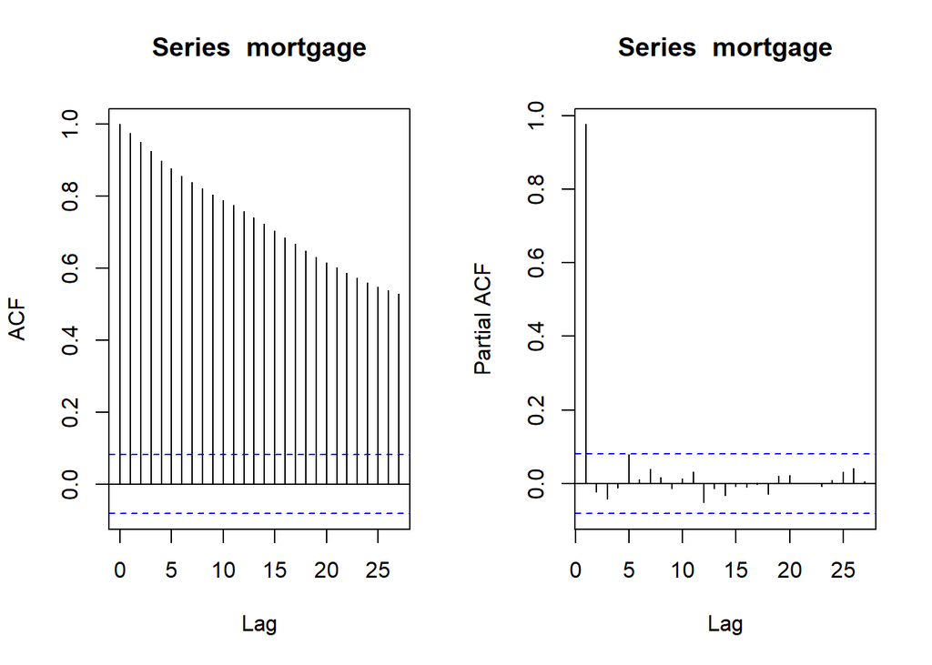

```r
par(mfrow=c(1,2))
acf(mortgage)
pacf(mortgage)
```

From the plot of timeseries, it is evident that the time series is non stationary. Also the ACF decreases gradually which implies that thge time series s non stationary. Let us perform the ADF test for non-stationarity.

2)Identification of the non-stationarity of the time series

```r
adf.test(mortgage)
```

```
##
##  Augmented Dickey-Fuller Test
##
## data:  mortgage
## Dickey-Fuller = -2.4764, Lag order = 8, p-value = 0.3767
## alternative hypothesis: stationary
```

```r
test1<-ur.df(mortgage,type="drift", lags = 8)
summary(test1)
```

```
##
## ###############################################
## # Augmented Dickey-Fuller Test Unit Root Test #
## ###############################################
##
## Test regression drift
##
##
## Call:
## lm(formula = z.diff ~ z.lag.1 + 1 + z.diff.lag)
##
## Residuals:
##      Min       1Q   Median       3Q      Max
## -0.22903 -0.04575 -0.00500  0.03759  0.52021
##
## Coefficients:
##              Estimate Std. Error t value Pr(>|t|)
## (Intercept)  0.060846   0.026993   2.254   0.0246 *
## z.lag.1     -0.015040   0.006397  -2.351   0.0191 *
## z.diff.lag1  0.034969   0.042099   0.831   0.4065
## z.diff.lag2  0.084459   0.042083   2.007   0.0452 *
## z.diff.lag3  0.013305   0.041887   0.318   0.7509
## z.diff.lag4  0.044662   0.041910   1.066   0.2870
## z.diff.lag5 -0.030559   0.040931  -0.747   0.4556
## z.diff.lag6  0.014919   0.040974   0.364   0.7159
## z.diff.lag7 -0.050975   0.040770  -1.250   0.2117
## z.diff.lag8  0.051897   0.040797   1.272   0.2039
## ---
## Signif. codes:  0 '***' 0.001 '**' 0.01 '*' 0.05 '.' 0.1 ' ' 1
##
## Residual standard error: 0.07569 on 559 degrees of freedom
## Multiple R-squared:  0.02667,    Adjusted R-squared:  0.011
## F-statistic: 1.702 on 9 and 559 DF,  p-value: 0.08548
##
##
## Value of test-statistic is: -2.3511 2.9951
##
## Critical values for test statistics:
##       1pct  5pct 10pct
## tau2 -3.43 -2.86 -2.57
## phi1  6.43  4.59  3.78
```

The test statistic is not more negative than the critical values, hence we conclude that the time series is non-stationary with a drift

3. Parameter estimation

```r
mortgage.diff.one<-diff(mortgage)
adf.test(mortgage.diff.one)
```

```
##
##  Augmented Dickey-Fuller Test
##
## data:  mortgage.diff.one
## Dickey-Fuller = -8.0634, Lag order = 8, p-value = 0.01
## alternative hypothesis: stationary
```

After taking the first order difference, we get a p-value of 0.01 which is less than 0.05. Hence we reject the null hypothesis that the time series is non-stationary and conclude that the time series is stationary.

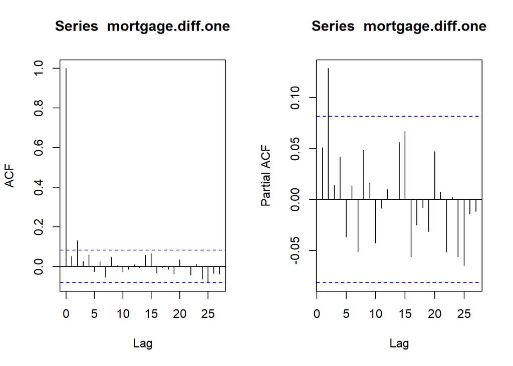

```r
par(mfrow=c(1,2))
acf(mortgage.diff.one)
pacf(mortgage.diff.one)
```

The plot shows that the ACF cutts of at 2 and the PACF cutts off at 2. Lets fit an ARMA(2,2) model

```r
Arima(mortgage,order=c(2,1,2))
```

```
## Series: mortgage
## ARIMA(2,1,2)
##
## Coefficients:
##           ar1     ar2     ma1      ma2
##       -0.1713  0.5622  0.2246  -0.4294
## s.e.   0.1863  0.1736  0.2020   0.1870
##
## sigma^2 estimated as 0.006115:  log likelihood=653.73
## AIC=-1297.45   AICc=-1297.35   BIC=-1275.66
```

```r
#Checking for other models
Arima(mortgage,order=c(2,1,1))
```

```
## Series: mortgage
## ARIMA(2,1,1)
##
## Coefficients:
##          ar1     ar2      ma1
##       0.2660  0.1183  -0.2229
## s.e.  0.3395  0.0500   0.3425
##
## sigma^2 estimated as 0.006128:  log likelihood=652.63
## AIC=-1297.25   AICc=-1297.18   BIC=-1279.82
```

We see that ARIMA(2,1,2) has the lowest AIC, hence let’s fit this model.

```r
model<-Arima(mortgage,order=c(2,1,2))
```

We see that ar1 is not significant,ma1 is also not significant. We fit the final model by fixing the ar1 and ma1 to 0.

```r
model.revised<-Arima(mortgage,order=c(2,1,2),fixed=c(0,NA,0,NA))
```

4. Diagnostic checking

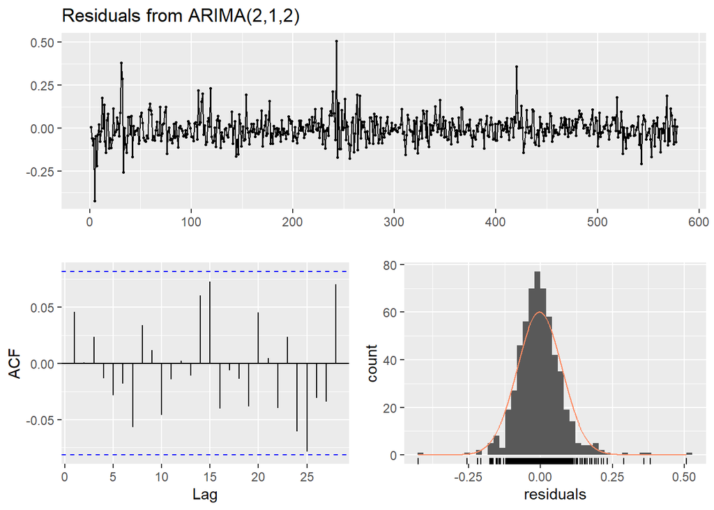

```
##
##  Ljung-Box test
##
## data:  Residuals from ARIMA(2,1,2)
## Q* = 6.2337, df = 6, p-value = 0.3975
##
## Model df: 4.   Total lags used: 10
```

```r
checkresiduals(model.revised)
```

We observe that the residuals are random and the ACF is not significant. The p-value is greater than 0.05 hence we cannot reject the null hypotheses that the residuals are white noise

5)Forecast for next 50 weeks

```r
forecast(model.revised,h=50)
```

```
##     Point Forecast    Lo 80    Hi 80    Lo 95    Hi 95
## 579       3.664420 3.564199 3.764642 3.511145 3.817696
## 580       3.672269 3.530535 3.814004 3.455505 3.889034
## 581       3.663575 3.482563 3.844587 3.386742 3.940409
## 582       3.667955 3.454785 3.881126 3.341939 3.993972
## 583       3.663104 3.418727 3.907480 3.289361 4.036846
## 584       3.665548 3.393521 3.937574 3.249519 4.081576
## 585       3.662840 3.364156 3.961524 3.206043 4.119638
## 586       3.664204 3.341055 3.987354 3.169989 4.158419
## 587       3.662693 3.316032 4.009355 3.132520 4.192867
## 588       3.663455 3.294778 4.032132 3.099612 4.227298
## 589       3.662611 3.272773 4.052450 3.066405 4.258818
## 590       3.663036 3.253128 4.072945 3.036136 4.289937
## 591       3.662566 3.233327 4.091804 3.006102 4.319030
## 592       3.662803 3.215067 4.110538 2.978051 4.347555
```

[output cut: 36 more lines]

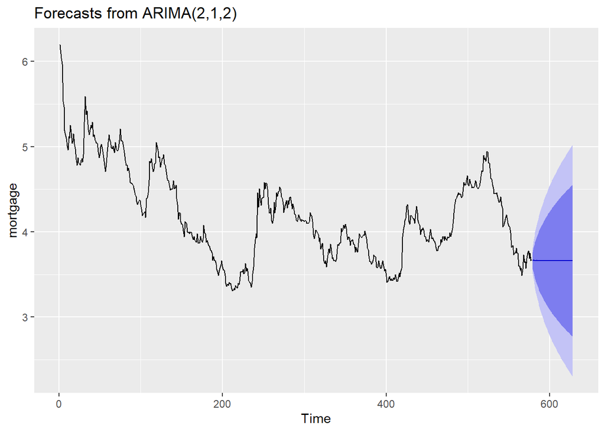

```r
autoplot(forecast(model.revised,h=50))
```